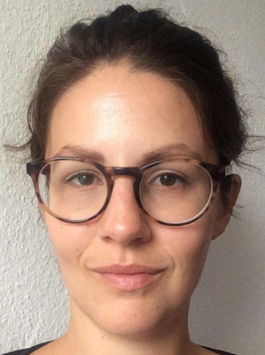

# Daniela Palleschi

[Twitter](https://twitter.com/dpalleswho) [Github](https://github.com/daniela-palleschi) [GitLab](https://scm.cms.hu-berlin.de/pallescd) [Google Scholar](https://scholar.google.com/citations?user=3hLUG68AAAAJ&hl=en)

I am currently a scientific support staff member for data science and data management support at the [Leibniz-Centre General Linguistics](https://www.leibniz-zas.de/de/) (ZAS: Leibniz-Zentrum Allgemeine Sprachwissenschaft). I was formerly a scientific staff member (research staff) and statistics consultant at the Institute of German Language and Linguistics at the Humboldt-Universität zu Berlin where I also completed my doctorate under the supervision of Prof. Pia Knoeferle. During my PhD I was a doctoral fellow at the Einstein Center for Neurosciences at the Charité - Universitätsmedizin Berlin, and part of the doctoral program at the Berlin School of Mind and Brain. My research interests include the processing of temporal relations and high-level real-world knowledge, and language processing more broadly.

## Contact

| Email | palleschi [at] leibniz [dash] zas [dot] de (N.B., I don't speak Italian!) |
| --- | --- |
| Sitz | Room 1.08, Leibniz-Zentrum Allgemeine Sprachwissenschaft (ZAS), Pariser Str. 1, 10719 Berlin |

## News

In **May 2025** I had a [new article published](https://doi.org/10.5070/G6011.19481) in *Glossa Pscycholinguistics*.

I was on parental leave from **October 2024 until December 2025**.

On **September 1st, 2024** I started a new position at the [Leibniz-Centre General Linguistics](https://www.leibniz-zas.de/de/) (ZAS: Leibniz-Zentrum Allgemeine Sprachwissenschaft) as research support staff for data science and data management.

In **September 2024** I had a poster at the 30th [AMLaP](https://amlap2024.ed.ac.uk/) (Architectures and Mechanisms for Language Processing) in Edinburgh, Scotland.

In **August 2024** I gave a workshop at the [Summer School of Linguistics](https://ssol.ff.cuni.cz/ssol-2024/) entitled *Open Science Practices for Linguistic Research: Reproducible Analyses in R* in České Budějovice (Budweis), Czechia.

In **May 2024** I gave a talk entitled *Elvis is dead: lifeme-tense congruence effects for the past, present (perfect), and future* at [Chronos 15](https://chronos15.sciencesconf.org/) in Toulouse, France. The abstract for the talk is on pages 27-28 in the [book of abstracts](https://chronos15.sciencesconf.org/data/pages/book_chronos15.pdf).

On **April 8th, 2024** I successfully defended my doctoral thesis!

In **June 2023** I submitted my [doctoral thesis](https://twitter.com/dpalleswho/status/1671621403240480774)!

In **February 2023** I started a new position as a statistics consultant for the Institut für deutsche Sprache und Linguistik at the Humboldt-Universität zu Berlin.